# STAT 380 Homework Exercises

MDSR Chapter 08

Kimberly Mincin

Due: 24/02/2019

# Front matter

```r
# always clean up R environment
rm(list = ls())
# load all packages here
library(NHANES)
library(rpart)
library(randomForest)
library(class)
library(e1071)
library(nnet)
library(glmnet)
library(partykit)
```

```r
SleepHabits <-
  NHANES %>%
  select("SleepTrouble", "PhysActive", "Age", "Pulse", "Poverty", "DaysMentHlthBad",
         "BMI", "Gender", "DaysPhysHlthBad") %>%
  na.omit()
```

```r
pairs(SleepHabits)
```

# Exercises

### Exercise 8.1

Null Model

```r
mod_null <- tally(~SleepTrouble, data = SleepHabits, format = "percent")
mod_null
```

```
SleepTrouble
      No      Yes
74.20016 25.79984
```

The Null model is accurate 74.20 % of the time by simply guessing no for each cases in the data.

Logistic Regression

```r
mod_logit <- glm(SleepTrouble ~ ., data = SleepHabits, family = "binomial")
msummary(mod_logit)
```

```
Coefficients:
                 Estimate Std. Error z value Pr(>|z|)
(Intercept)     -3.084632   0.270772 -11.392  < 2e-16 ***
PhysActiveYes    0.213427   0.064980   3.285 0.001022 **
Age              0.017752   0.001806   9.827  < 2e-16 ***
Pulse            0.006177   0.002646   2.334 0.019591 *
Poverty         -0.011103   0.019236  -0.577 0.563808
DaysMentHlthBad  0.053471   0.003623  14.760  < 2e-16 ***
BMI              0.016084   0.004441   3.622 0.000293 ***
Gendermale      -0.347679   0.061021  -5.698 1.21e-08 ***
DaysPhysHlthBad  0.031304   0.003793   8.252  < 2e-16 ***

(Dispersion parameter for binomial family taken to be 1)

    Null deviance: 7245.4  on 6344  degrees of freedom
Residual deviance: 6705.3  on 6336  degrees of freedom
AIC: 6723.3

Number of Fisher Scoring iterations: 4
```

```r
SleepTrouble_logitProb <- predict(mod_logit, newdata = NHANES, type = "response")
SleepTrouble_logit <- ifelse(SleepTrouble_logitProb > .5, yes = "yes", "no")
confusion <- tally(SleepTrouble_logit ~ SleepTrouble, data = NHANES, format = "count")
confusion
```

```
                  SleepTrouble
SleepTrouble_logit   No  Yes <NA>
              no   4526 1396  514
              yes   182  241    2
              <NA> 1091  336 1712
```

```r
logit_acc <- sum(diag(confusion)) / nrow(NHANES) * 100
logit_acc
```

```
[1] 64.79
```

The logistic regression model is accurate 64.79 % of the time. This is worse than the null model.

Decision Tree

```r
mod_tree <- rpart(SleepTrouble ~ ., data = SleepHabits)
mod_tree
```

```
n= 6345

node), split, n, loss, yval, (yprob)
      * denotes terminal node

 1) root 6345 1637 No (0.7420016 0.2579984)
   2) DaysMentHlthBad< 5.5 5111 1106 No (0.7836040 0.2163960) *
   3) DaysMentHlthBad>=5.5 1234  531 No (0.5696921 0.4303079)
     6) DaysPhysHlthBad< 0.5 642  210 No (0.6728972 0.3271028) *
     7) DaysPhysHlthBad>=0.5 592  271 Yes (0.4577703 0.5422297)
      14) DaysMentHlthBad< 19.5 331  147 No (0.5558912 0.4441088) *
      15) DaysMentHlthBad>=19.5 261   87 Yes (0.3333333 0.6666667) *
```

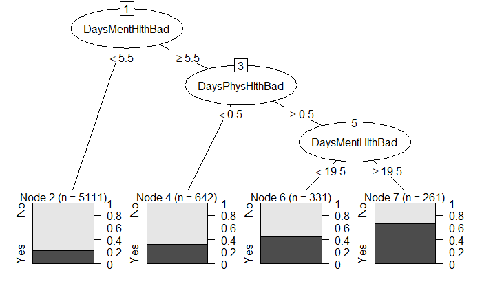

```r
plot(as.party(mod_tree))
```

```r
Sleep_tree <-
  SleepHabits %>%
  mutate(sleep_dtree = predict(mod_tree, type = "class"))
confusion <- tally(sleep_dtree ~ SleepTrouble, data = Sleep_tree, format = "count")
confusion
```

```
           SleepTrouble
sleep_dtree   No  Yes
        No  4621 1463
        Yes   87  174
```

```r
sum(diag(confusion)) / nrow(SleepHabits) * 100
```

```
[1] 75.57132
```

The decision tree is accurate 75.57 % of the time. This is slightly better than the null model.

Random Forest

```r
mod_forest <- randomForest(SleepTrouble ~ ., data = SleepHabits, ntree = 2000, mtry =3)
mod_forest
```

```
Call:
 randomForest(formula = SleepTrouble ~ ., data = SleepHabits,      ntree = 2000, mtry = 3)
               Type of random forest: classification
                     Number of trees: 2000
No. of variables tried at each split: 3

        OOB estimate of  error rate: 10.07%
Confusion matrix:
      No  Yes class.error
No  4573  135   0.0286746
Yes  504 1133   0.3078803
```

```r
rf_acc <- sum(diag(mod_forest$confusion)) / nrow(SleepHabits) * 100
rf_acc
```

```
[1] 89.92908
```

The random forest is accurate 89.93 % of the time. This is much better than the null model, and might indicate overfitting the data.

Neural Network

```r
mod_nnet <- nnet(SleepTrouble ~ ., data = SleepHabits, size = 3)
SleepTrouble_nn <- predict(mod_nnet, newdata = SleepHabits, type = "class")
confusion <- tally(SleepTrouble_nn ~ SleepTrouble, data = SleepHabits, format = "count")
confusion
```

```
               SleepTrouble
SleepTrouble_nn   No  Yes
            No  4395 1236
            Yes  313  401
```

```r
nnet_acc <- sum(diag(confusion)) / nrow(NHANES) * 100
nnet_acc
```

```
[1] 47.96
```

The Neural network is accurate 47.96 % of the time. This is noticeably worse than the null model, so the neural network is not a good predictor for the data.

Naive Bayes

```r
mod_nb <- naiveBayes(SleepTrouble ~ ., data = SleepHabits)
SleepTrouble_nb <- predict(mod_nb, newdata = SleepHabits)
confusion <- tally(SleepTrouble_nb ~ SleepTrouble, data = SleepHabits, format = "count")
confusion
```

```
               SleepTrouble
SleepTrouble_nb   No  Yes
            No  4229 1201
            Yes  479  436
```

```r
nb_acc <- sum(diag(confusion)) / nrow(SleepHabits) * 100
nb_acc
```

```
[1] 73.52246
```

The Naive Bayes model is accurate 73.52 % of the time. This is better than the neural network but still slightly worse than the null model.

k-NN

```r
SleepTrouble_knn <- knn(train = SleepHabits, test = SleepHabits, cl = SleepHabits$SleepTrouble, k = 5)
```

```
NAs introduced by coercionNAs introduced by coercionError in knn(train = SleepHabits, test = SleepHabits, cl = SleepHabits$SleepTrouble,  :
  NA/NaN/Inf in foreign function call (arg 6)
```

### Exercise 8.2

Null Model

```r
mod_null <- tally(~ SleepTrouble, data = NHANES, format = "percent")
mod_null
```

```
SleepTrouble
   No   Yes  <NA>
57.99 19.73 22.28
```

Multiple Regression

Regression Tree

Random Forest

```r
mod_Forest <- randomForest(SleepTrouble ~ SleepHrsNight, data = NHANES, ntree = 2000, mtry =2)
```

```
Error in na.fail.default(list(SleepTrouble = c(2L, 2L, 2L, NA, 2L, NA,  :
  missing values in object
```

Ridge Regression

LASSO

```r
NHANES_matrix <-
  NHANES %>%
  mutate(yes = ifelse(NHANES$SleepTrouble == "yes", 1, 0)) %>%
  as.matrix()
mod_lasso <- glmnet(x = NHANES_matrix, y = NHANES$SleepTrouble, family = "binomial", alpha = 1)
```

```
Error in if (!all(o)) { : missing value where TRUE/FALSE needed
```

### Exercise 8.3

```r
set.seed(144)
n <- nrow(NHANES)
test_idx <- sample.int(n, size = round(0.25 * n)) # select row numbers for the test set
train <- NHANES[-test_idx, ]  # exclude the test set cases
nrow(train)
```

```
[1] 7500
```

```r
test <- NHANES[test_idx, ]    # test set cases only
nrow(test)
```

```
[1] 2500
```